# Financial Analysis of Field of Studies - Bachelor Degrees in US

Going to College is one of the biggest financial decisions a family or a young adult will have to make. Recently (as of late 2019) the US Department of Education made available the earnings by Field of Study for hundreds of institutions. The tool provided by the US Department of education:

https://collegescorecard.ed.gov/

It is really good, if the student has already decided the field of study or the institutions where he/she would like to apply. Having said this, the tool does not provide an easy way to compare the financial benefit of one degree versus another; or the financial benefit of choosing one institution versus all others that offer the same degree.

The US department of education , provides the option to download the data sets used in the tool from the following website:

https://collegescorecard.ed.gov/data/

The analsysis uses the data in the file FieldOfStudyData1516_1617_PP.csv; combining it with Institution information to display a financial comparison of programs. The Earning by Field of study data shows the Median Earnings (and Debt) of Students as of 1 year after graduation for the classes 2015_16 anf 2016_17.

```r
FieldofStudy_Earnings_for_rep = read.csv("C:/Users/figue/Documents/Collegeboard_data/June_2020_Update/Field_of_Studies_Earn_rep.csv", stringsAsFactors = FALSE)
dim(FieldofStudy_Earnings_for_rep)
```

```
## [1] 19112    14
```

```r
colnames(FieldofStudy_Earnings_for_rep)
```

```
##  [1] "P_INSTNM"           "P_MAIN"             "P_CIPDESC"
##  [4] "STABBR"             "P_DEBTMEDIAN"       "P_MD_EARN_WNE"
##  [7] "ADM_RATE"           "SAT_AVG"            "Tuition_Average"
## [10] "Tuition_more_110K"  "Debt_payback_YR"    "Tuit_Avg_4Y_Pyback"
## [13] "Tuit_Inc_4Y_Pyback" "Salary_10Y_4Y_Tui"
```

```r
#Change colnames to what they used to be
colnames(FieldofStudy_Earnings_for_rep)=c( "INSTNM","MAIN","CIPDESC","STABBR","DEBTMEDIAN","MD_EARN_WNE","ADM_RATE","SAT_AVG","Tuition_Average","Tuition_more_110K","Debt_payback_YR","Tuit_Avg_4Y_Pyback","Tuit_Inc_4Y_Pyback","Salary_10Y_4Y_Tui"    )
colnames(FieldofStudy_Earnings_for_rep)
```

```
##  [1] "INSTNM"             "MAIN"               "CIPDESC"
##  [4] "STABBR"             "DEBTMEDIAN"         "MD_EARN_WNE"
##  [7] "ADM_RATE"           "SAT_AVG"            "Tuition_Average"
## [10] "Tuition_more_110K"  "Debt_payback_YR"    "Tuit_Avg_4Y_Pyback"
## [13] "Tuit_Inc_4Y_Pyback" "Salary_10Y_4Y_Tui"
```

The following is a brief description of the columns.

**INSTNM:** Institution Name.  
**MAIN:** If reads 1 if it is the main campus for the institution otherwise reads 0.  
**CIPDESC:** The description of the Field of Study.  
**STABBR:** State where the Institution is located.  
**DEBTMEDIAN:** The Median Amount of debt of studends graduating from that institution with that field of study.  
**MD_EARN_WNE:** Median Earnings of the students of the field of study from the specific institution 1 year after graduation.  
**ADM_RATE:** Overall Admission rate for the Institution.  
**SAT_AVG:** SAT Average Score of all Students accepted by the Institution (independently of Field of Study).  
**Tuition_Average:** Average Tuition paid by students at Institution (independently of Field of Study).  
**Tuition_more_110K:** Average Tuition paid by students, belonging to families with incomes of more than 110K per year, at Institution (independently of Field of Study).  
**Debt_payback_YR:** Number of years to pay median debt based on earnings 1 year after graduation (if all earnings were used to pay debt).  
**Tuit_Avg_4Y_Pyback:** Number of years to payback 4 years of Average Tuition based on earnings 1 year after migration (if all earnings were used to pay debt).  
**Tuit_Inc_4Y_Pyback:** Number of years to payback 4 years of Tuition (Family Income >110K) based on earnings 1 year after migration (if all earnings were used to pay debt).  
**Salary_10Y_4Y_Tui:** Potential Total Earnings 10 Years after graduation after paying 4 Years of Average Tuition.

The last 4 columns are calculated columns, All others come directly from the college scorecard data files.

There are more than 300 Field of Studies for Bachelor Degrees however the most popular (more than 50 institutions offer these) are listed following.

```r
FieldofStudy_Earnings_for_rep_count = aggregate(INSTNM ~ CIPDESC,data= FieldofStudy_Earnings_for_rep, length)

FieldofStudy_Earnings_for_rep_count=FieldofStudy_Earnings_for_rep_count[order(FieldofStudy_Earnings_for_rep_count$INSTNM,decreasing=TRUE),]

FieldofStudy_Earnings_for_rep_count[FieldofStudy_Earnings_for_rep_count$INSTNM>49,]
```

|  | CIPDESC | INSTNM |
| --- | --- | --- |
| 47 | Business Administration, Management and Operations. | 1089 |
| 233 | Psychology, General. | 852 |
| 243 | Registered Nursing, Nursing Administration, Nursing Research and Clinical Nursing. | 802 |
| 41 | Biology, General. | 647 |
| 82 | Criminal Justice and Corrections. | 618 |
| 1 | Accounting and Related Services. | 603 |
| 268 | Teacher Education and Professional Development, Specific Levels and Methods. | 567 |
| 62 | Communication and Media Studies. | 538 |
| 113 | English Language and Literature, General. | 454 |
| 144 | Health and Physical Education/Fitness. | 404 |
| 187 | Marketing. | 403 |
| 230 | Political Science and Government. | 374 |
| 259 | Sociology. | 364 |
| 178 | Liberal Arts and Sciences, General Studies and Humanities. | 363 |
| 124 | Finance and Financial Management Services. | 335 |
| 125 | Fine and Studio Arts. | 334 |
| 69 | Computer and Information Sciences, General. | 319 |
| 150 | History. | 319 |
| 257 | Social Work. | 290 |
| 269 | Teacher Education and Professional Development, Specific Subject Areas. | 287 |
| 194 | Mechanical Engineering. | 277 |
| 96 | Economics. | 272 |
| 90 | Design and Applied Arts. | 231 |
| 50 | Business/Commerce, General. | 218 |
| 73 | Computer Science. | 205 |
| 102 | Electrical, Electronics and Communications Engineering. | 205 |
| 143 | Health and Medical Administrative Services. | 200 |
| 58 | Civil Engineering. | 184 |
| 192 | Mathematics. | 171 |
| 93 | Drama/Theatre Arts and Stagecraft. | 166 |
| 205 | Natural Resources Conservation and Research. | 166 |
| 250 | Romance Languages, Literatures, and Linguistics. | 156 |
| 158 | Human Resources Management and Services. | 152 |
| 202 | Multi/Interdisciplinary Studies, Other. | 151 |
| 172 | Journalism. | 145 |
| 203 | Music. | 145 |
| 239 | Public Relations, Advertising, and Applied Communication. | 135 |
| 54 | Chemical Engineering. | 129 |
| 157 | Human Development, Family Studies, and Related Services. | 127 |
| 261 | Special Education and Teaching. | 126 |
| 18 | Anthropology. | 125 |
| 237 | Public Health. | 125 |
| 123 | Film/Video and Photographic Arts. | 123 |
| 153 | Hospitality Administration/Management. | 122 |
| 182 | Management Information Systems and Services. | 121 |
| 14 | Allied Health Diagnostic, Intervention, and Treatment Professions. | 119 |
| 55 | Chemistry. | 113 |
| 71 | Computer Engineering. | 110 |
| 162 | Information Science/Studies. | 100 |
| 241 | Radio, Television, and Digital Communication. | 99 |
| 146 | Health Services/Allied Health/Health Sciences, General. | 98 |
| 249 | Rhetoric and Composition/Writing Studies. | 97 |
| 83 | Criminology. | 87 |
| 170 | International Relations and National Security Studies. | 87 |
| 27 | Architecture. | 74 |
| 183 | Management Sciences and Quantitative Methods. | 71 |
| 17 | Animal Sciences. | 69 |
| 63 | Communication Disorders Sciences and Services. | 67 |
| 169 | International Business. | 66 |
| 37 | Biochemistry, Biophysics and Molecular Biology. | 65 |
| 171 | International/Global Studies. | 64 |
| 136 | Geography and Cartography. | 62 |
| 137 | Geological and Earth Sciences/Geosciences. | 62 |
| 43 | Biomedical/Medical Engineering. | 61 |
| 159 | Human Services, General. | 60 |
| 77 | Computer/Information Technology Administration and Management. | 58 |
| 160 | Industrial Engineering. | 57 |
| 255 | Social Sciences, General. | 57 |
| 52 | Business/Managerial Economics. | 56 |
| 74 | Computer Software and Media Applications. | 56 |
| 5 | Agricultural Business and Management. | 55 |
| 2 | Aerospace, Aeronautical and Astronautical Engineering. | 51 |
| 60 | Clinical/Medical Laboratory Science/Research and Allied Professions. | 51 |
| 91 | Dietetics and Clinical Nutrition Services. | 51 |
| 180 | Linguistic, Comparative, and Related Language Studies and Services. | 51 |

The statistical analysis will be done for these Fields of Study. Histograms will be created based on Salary_10Y_4Y_Tui field. The histograms will be created for the Top 10 and Bottom 10 Fields of Study based on Financial Outcome using the this field.

```r
FieldofStudy_Earnings_for_rep_avg = aggregate(Salary_10Y_4Y_Tui ~ CIPDESC,data= FieldofStudy_Earnings_for_rep, mean)
FieldofStudy_Earnings_for_rep_avg=FieldofStudy_Earnings_for_rep_avg[order(FieldofStudy_Earnings_for_rep_avg$Salary_10Y_4Y_Tui,decreasing=TRUE),]

#make sure they are popular
FieldofStudy_Earnings_for_rep_avg = FieldofStudy_Earnings_for_rep_avg[FieldofStudy_Earnings_for_rep_avg$CIPDESC %in% FieldofStudy_Earnings_for_rep_count[FieldofStudy_Earnings_for_rep_count$INSTNM>49,"CIPDESC"],]

#Mean Earnings all fields of study
mean(FieldofStudy_Earnings_for_rep_avg$Salary_10Y_4Y_Tui)
```

```
## [1] 313638.6
```

```r
#Top 10
FieldofStudy_Earnings_for_rep_top10 = head(FieldofStudy_Earnings_for_rep_avg,10)
FieldofStudy_Earnings_for_rep_top10
```

|  | CIPDESC | Salary_10Y_4Y_Tui |
| --- | --- | --- |
| 71 | Computer Engineering. | 595635.7 |
| 102 | Electrical, Electronics and Communications Engineering. | 588338.1 |
| 73 | Computer Science. | 585351.2 |
| 160 | Industrial Engineering. | 562323.0 |
| 54 | Chemical Engineering. | 548683.1 |
| 243 | Registered Nursing, Nursing Administration, Nursing Research and Clinical Nursing. | 547745.9 |
| 194 | Mechanical Engineering. | 540956.8 |
| 2 | Aerospace, Aeronautical and Astronautical Engineering. | 537554.1 |
| 58 | Civil Engineering. | 504065.3 |
| 69 | Computer and Information Sciences, General. | 489407.0 |

```r
#Bottom 10
FieldofStudy_Earnings_for_rep_bottom10 = tail(FieldofStudy_Earnings_for_rep_avg,10)
FieldofStudy_Earnings_for_rep_bottom10
```

|  | CIPDESC | Salary_10Y_4Y_Tui |
| --- | --- | --- |
| 63 | Communication Disorders Sciences and Services. | 198909.4 |
| 241 | Radio, Television, and Digital Communication. | 198729.9 |
| 249 | Rhetoric and Composition/Writing Studies. | 196252.6 |
| 113 | English Language and Literature, General. | 193951.4 |
| 180 | Linguistic, Comparative, and Related Language Studies and Services. | 188759.2 |
| 18 | Anthropology. | 175779.3 |
| 203 | Music. | 170315.5 |
| 125 | Fine and Studio Arts. | 162548.4 |
| 123 | Film/Video and Photographic Arts. | 133695.9 |
| 93 | Drama/Theatre Arts and Stagecraft. | 125600.2 |

**Histograms for Top 10.**

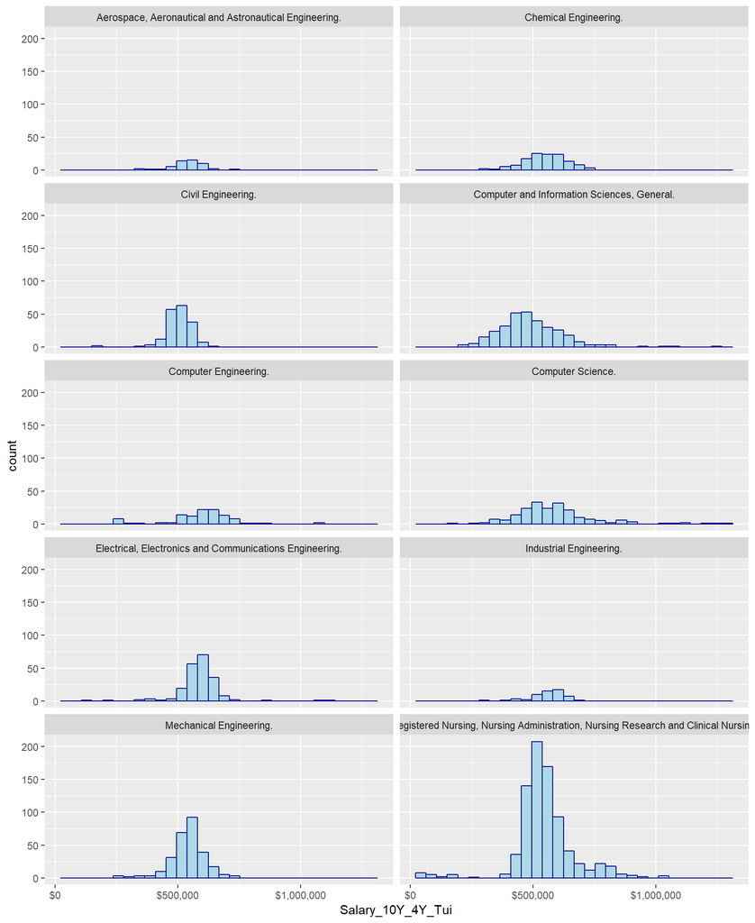

```r
library(ggplot2)
library(scales)

df_top10 = FieldofStudy_Earnings_for_rep[FieldofStudy_Earnings_for_rep$CIPDESC %in% FieldofStudy_Earnings_for_rep_top10$CIPDESC,]
# Change line color and fill color
ggplot(df_top10, aes(x=Salary_10Y_4Y_Tui))+  geom_histogram(color="darkblue", fill="lightblue") + scale_x_continuous(labels=dollar_format()) + facet_wrap(. ~ CIPDESC, ncol = 2)
```

Histograms for Bottom 10.

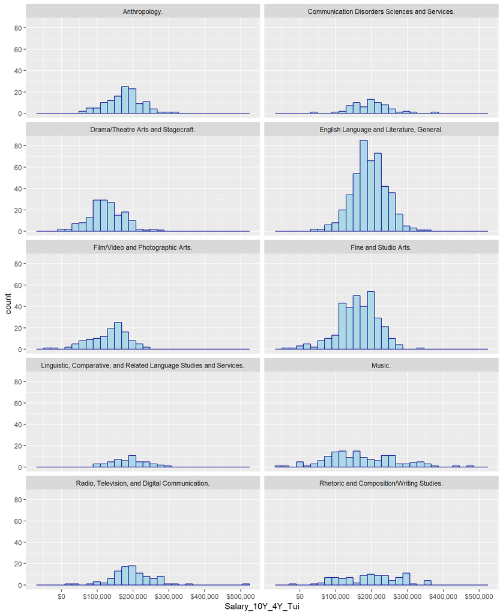

```r
df_bottom10 = FieldofStudy_Earnings_for_rep[FieldofStudy_Earnings_for_rep$CIPDESC %in% FieldofStudy_Earnings_for_rep_bottom10$CIPDESC,]
# Change line color and fill color
ggplot(df_bottom10, aes(x=Salary_10Y_4Y_Tui))+  geom_histogram(color="darkblue", fill="lightblue") + scale_x_continuous(labels=dollar_format()) + facet_wrap(. ~ CIPDESC, ncol = 2)
```

Now find the Field of Studies with the greater variance in outcomes. This means, that there is an important financial difference depending on the institution for these fields of study.

```r
FieldofStudy_Earnings_for_rep_sdev = aggregate(Salary_10Y_4Y_Tui ~ CIPDESC,data= FieldofStudy_Earnings_for_rep, sd)
FieldofStudy_Earnings_for_rep_sdev = FieldofStudy_Earnings_for_rep_sdev[order(FieldofStudy_Earnings_for_rep_sdev$Salary_10Y_4Y_Tui,decreasing=TRUE),]

#make sure they are popular
FieldofStudy_Earnings_for_rep_sdev = FieldofStudy_Earnings_for_rep_sdev[FieldofStudy_Earnings_for_rep_sdev$CIPDESC %in% FieldofStudy_Earnings_for_rep_count[FieldofStudy_Earnings_for_rep_count$INSTNM>49,"CIPDESC"],]



#Top 10
FieldofStudy_Earnings_for_rep_top10_sdev = head(FieldofStudy_Earnings_for_rep_sdev,10)
FieldofStudy_Earnings_for_rep_top10_sdev
```

|  | CIPDESC | Salary_10Y_4Y_Tui |
| --- | --- | --- |
| 14 | Allied Health Diagnostic, Intervention, and Treatment Professions. | 167845.0 |
| 73 | Computer Science. | 166700.8 |
| 71 | Computer Engineering. | 141254.6 |
| 69 | Computer and Information Sciences, General. | 130660.4 |
| 74 | Computer Software and Media Applications. | 127350.7 |
| 243 | Registered Nursing, Nursing Administration, Nursing Research and Clinical Nursing. | 120896.4 |
| 192 | Mathematics. | 110346.2 |
| 146 | Health Services/Allied Health/Health Sciences, General. | 107583.4 |
| 96 | Economics. | 104462.9 |
| 183 | Management Sciences and Quantitative Methods. | 103235.7 |

For the field of studies in the previous table , it would be a good idea to check the Institutions that offer the best financial outcomes. The following are the histograms.

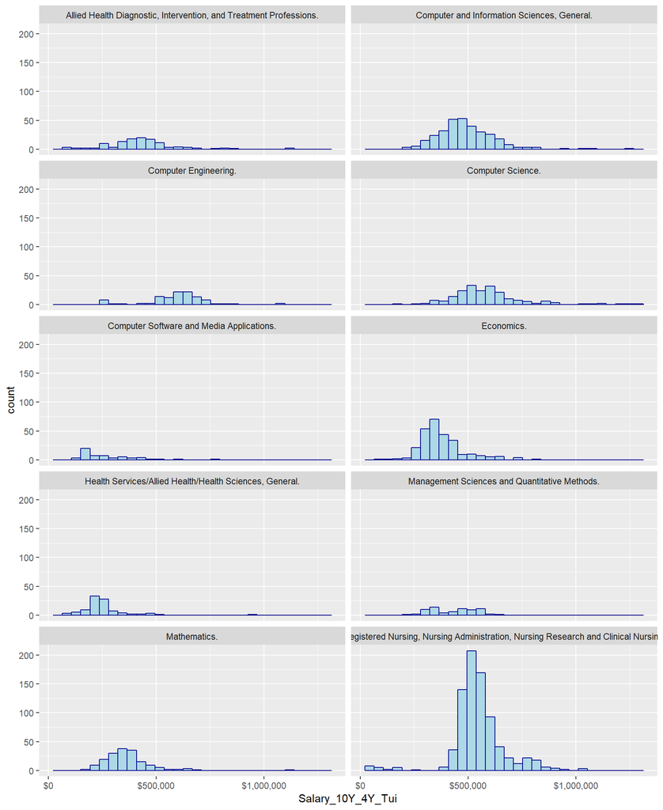

```r
df_sdev10 = FieldofStudy_Earnings_for_rep[FieldofStudy_Earnings_for_rep$CIPDESC %in% FieldofStudy_Earnings_for_rep_top10_sdev$CIPDESC,]
# Change line color and fill color
ggplot(df_sdev10, aes(x=Salary_10Y_4Y_Tui))+  geom_histogram(color="darkblue", fill="lightblue") + scale_x_continuous(labels=dollar_format()) + facet_wrap(. ~ CIPDESC, ncol = 2)
```

The following box plots focus on the 10 Field of Studies with the highest variance. It provides a view into the outliers.

```r
library(dplyr)
```

```r
library(ggplot2)


#function to determine outliers
#Increase IQR from 1.5 times to 2.0 times to avoid many outliers
is_outlier <- function(x) {
  return(x < quantile(x, 0.25) - 2.0 * IQR(x) | x > quantile(x, 0.75) + 2.0 * IQR(x))
}

#dat <- df_sdev10[,c("CIPDESC","INSTNM","Salary_10Y_4Y_Tui")] %>% group_by(CIPDESC) %>% mutate(is_outlier=ifelse(is_outlier(Salary_10Y_4Y_Tui),INSTNM,as.numeric(NA)))

#dat$INSTNM[which(is.na(dat$is_outlier))] <- as.numeric(NA)

#This ggplot view overlaps the names of many institutions
#ggplot(dat, aes(y=Salary_10Y_4Y_Tui, x=factor(CIPDESC))) + geom_boxplot() + geom_text(aes(label=INSTNM),na.rm=TRUE,nudge_y=0.5, cex=2, angle=45) + theme(axis.text.x =element_text(angle=45, hjust =1) )
```

Try yo use plotly to make it more readable

```r
library(plotly)
p <-  ggplot(df_sdev10, aes(y=Salary_10Y_4Y_Tui, x=factor(CIPDESC))) + geom_boxplot()  + theme(axis.text.x =element_text(angle=45, hjust =1) )


#store description as factor
temp = as.factor(df_sdev10$CIPDESC)
df_sdev10$factorCIPDESC_Salary = paste(as.numeric(temp),df_sdev10$Salary_10Y_4Y_Tui,sep="_")

#create plotly object

ply = ggplotly(p,  width = 1280, height = 960)


#maybe I can map ti with ply$x$data[[1]]$x and ply$x$data[[1]]$y
datafrom_ply = as.data.frame(cbind(ply$x$data[[1]]$x,ply$x$data[[1]]$y))
datafrom_ply$formatch = paste(datafrom_ply[,1],datafrom_ply[,2],sep="_")
#have to merge to align based on factor and dollar amount
#Add sequence to return to right order
datafrom_ply$seq = seq(1,dim(datafrom_ply)[1])

# there is duplicated data
#datafrom_ply[duplicated(datafrom_ply$formatch),]
#have to remove these duplicates from df_sdev10
#to avoid merging issues

df_sdev10_unique= df_sdev10[!duplicated(df_sdev10$factorCIPDESC_Salary),]

#merge changes the orger
datafrom_ply = merge(datafrom_ply, df_sdev10_unique[,c("factorCIPDESC_Salary","INSTNM","Salary_10Y_4Y_Tui","CIPDESC")], all.x=TRUE, all.y=FALSE, by.x="formatch", by.y="factorCIPDESC_Salary")
#reorder using the field seq
datafrom_ply=datafrom_ply[order(datafrom_ply$seq),]
#Now INSTNM should be ordered correctly
#Add field with dollar amoung and institution
datafrom_ply$INSTNM_Net_10 = paste(datafrom_ply$INSTNM,": $",datafrom_ply$Salary_10Y_4Y_Tui,sep="")

#Assign Labels to display
ply$x$data[[1]]$text = datafrom_ply$INSTNM_Net_10
ply$x$data[[1]]$hoverinfo <- "text"


ply
```

[interactive chart not shown]

This is the end of the basic statistic analsysis. Based on this please check the data tables available to search for a specific field of study and the best institutions (from a a financial perspective) that offers it.

There is a more advanced statistical analysis that review financial outcome by other variables like location and words included in the Field of Study.